# Medical Appointment No Show Exploratory Analysis

> *steps to follow :*
> - **1-select project dataset**
> - **2-perform data preparation and cleaning using pandas and numpy**
> - **3-perform exploratory analysis and visualization using matplot lib**
> - **4-ask and answer questions about data in jupyter notebook**
> - **5-summarize results and write conclusion**
> - **6- document jupyter notebook**
- Introduction
- Data Preparation And Cleaning
- Data Preparation And Cleaning
- Questions to ask
- Limitations
- Conclusions

## Introduction

> *To Do List :*
> - **over view about Bolsa Familia Programm**
> - **talk about the dataset (source , what it's contains , what beninfits we can get from it)**
>   - Kaggle
>   - contains informtion about governimental medical program in brazil
>   - how it's benifit to predicat the most causes that makes people NO Show for their medical appointement

Bolsa Família was a social welfare program of the Government of Brazil, part of the Fome Zero network of federal assistance programs. Bolsa Família provided financial aid to poor Brazilian families; and if they had children, families must ensure that the children attend school and are vaccinated. If they exceed the total of permitted school absences, they are dropped from the program and their funds are suspended. The program attempts to both reduce short-term poverty by direct cash transfers and fight long-term poverty by increasing human capital among the poor through conditional cash transfers. It also works to give free education to children who cannot afford to go to school to show the importance of education In 2008, The Economist described Bolsa Família as an "anti-poverty scheme invented in Latin America which is winning converts worldwide. This dataset collects information from 110k medical appointments in Brazil and is focused on the question of whether or not patients show up for their appointment. A number of characteristics about the patient are included in each row.

> *Data Definition*:
> - **PatientId:** it's unique identification number for each patient.
> - **AppointmentID:** it's an identification number for each appointment.
> - **Gender**: Male or Female.
> - **AppointmentDay:** date of actual appointment.
> - **ScheduledDay:** the day patient reserve for appointment.
> - **Age:** age of patient.
> - **Neighborhood:** the place that patient takes the servise.
> - **Scholarship:** 1 or 0.(goverenmental support to poor people to learn their kids)
> - **Hipertension:** 1 or 0.(chronical disease for high blood pressure)
> - **Diabetes:** 1 or 0. (chronical disease for high sugar percentage in blood)
> - **Alcoholism:** 1 or 0.(used to drink alcohol ... alcohol addict)
> - **Handcap:** 1 or 0.(have a physical body movement problem)
> - **SMS_received:** messeages sent to patient to insure the appointment date.
> - **No_show:** "Yes" or "No". (the status of attending the appointment on schedualed date or not).

## Data Download And Read

> - **load the file using pandas**
> - **review information within the file**
> - **Fix any incorrect Data types**
> - **Fix any missing values**

```python
import pandas as pd
import numpy as np
import matplotlib.pyplot as plt
%matplotlib inline
from datetime import datetime
```

```python
df = pd.read_csv('noshowappointments-kagglev2-may-2016.csv')
```

```python
df
```

|  | PatientId | AppointmentID | Gender | ScheduledDay | AppointmentDay | Age | Neighbourhood | Scholarship | Hipertension | Diabetes | Alcoholism | Handcap | SMS_received | No-show |
| --- | --- | --- | --- | --- | --- | --- | --- | --- | --- | --- | --- | --- | --- | --- |
| 0 | 2.987250e+13 | 5642903 | F | 2016-04-29T18:38:08Z | 2016-04-29T00:00:00Z | 62 | JARDIM DA PENHA | 0 | 1 | 0 | 0 | 0 | 0 | No |
| 1 | 5.589978e+14 | 5642503 | M | 2016-04-29T16:08:27Z | 2016-04-29T00:00:00Z | 56 | JARDIM DA PENHA | 0 | 0 | 0 | 0 | 0 | 0 | No |
| 2 | 4.262962e+12 | 5642549 | F | 2016-04-29T16:19:04Z | 2016-04-29T00:00:00Z | 62 | MATA DA PRAIA | 0 | 0 | 0 | 0 | 0 | 0 | No |
| 3 | 8.679512e+11 | 5642828 | F | 2016-04-29T17:29:31Z | 2016-04-29T00:00:00Z | 8 | PONTAL DE CAMBURI | 0 | 0 | 0 | 0 | 0 | 0 | No |
| 4 | 8.841186e+12 | 5642494 | F | 2016-04-29T16:07:23Z | 2016-04-29T00:00:00Z | 56 | JARDIM DA PENHA | 0 | 1 | 1 | 0 | 0 | 0 | No |
| ... | ... | ... | ... | ... | ... | ... | ... | ... | ... | ... | ... | ... | ... | ... |
| 110522 | 2.572134e+12 | 5651768 | F | 2016-05-03T09:15:35Z | 2016-06-07T00:00:00Z | 56 | MARIA ORTIZ | 0 | 0 | 0 | 0 | 0 | 1 | No |
| 110523 | 3.596266e+12 | 5650093 | F | 2016-05-03T07:27:33Z | 2016-06-07T00:00:00Z | 51 | MARIA ORTIZ | 0 | 0 | 0 | 0 | 0 | 1 | No |
| 110524 | 1.557663e+13 | 5630692 | F | 2016-04-27T16:03:52Z | 2016-06-07T00:00:00Z | 21 | MARIA ORTIZ | 0 | 0 | 0 | 0 | 0 | 1 | No |
| 110525 | 9.213493e+13 | 5630323 | F | 2016-04-27T15:09:23Z | 2016-06-07T00:00:00Z | 38 | MARIA ORTIZ | 0 | 0 | 0 | 0 | 0 | 1 | No |
| 110526 | 3.775115e+14 | 5629448 | F | 2016-04-27T13:30:56Z | 2016-06-07T00:00:00Z | 54 | MARIA ORTIZ | 0 | 0 | 0 | 0 | 0 | 1 | No |

110527 rows × 14 columns

```python
df.columns
```

```
Index(['PatientId', 'AppointmentID', 'Gender', 'ScheduledDay',
       'AppointmentDay', 'Age', 'Neighbourhood', 'Scholarship', 'Hipertension',
       'Diabetes', 'Alcoholism', 'Handcap', 'SMS_received', 'No-show'],
      dtype='object')
```

```python
df.info()
```

```
<class 'pandas.core.frame.DataFrame'>
RangeIndex: 110527 entries, 0 to 110526
Data columns (total 14 columns):
 #   Column          Non-Null Count   Dtype
---  ------          --------------   -----
 0   PatientId       110527 non-null  float64
 1   AppointmentID   110527 non-null  int64
 2   Gender          110527 non-null  object
 3   ScheduledDay    110527 non-null  object
 4   AppointmentDay  110527 non-null  object
 5   Age             110527 non-null  int64
 6   Neighbourhood   110527 non-null  object
 7   Scholarship     110527 non-null  int64
 8   Hipertension    110527 non-null  int64
 9   Diabetes        110527 non-null  int64
 10  Alcoholism      110527 non-null  int64
 11  Handcap         110527 non-null  int64
 12  SMS_received    110527 non-null  int64
 13  No-show         110527 non-null  object
dtypes: float64(1), int64(8), object(5)
memory usage: 11.8+ MB
```

```python
# change column No-show label
columns_label =list(df.columns)
columns_label[13] = 'No_show'
columns_label[6] = 'neighborhood'
df.columns = columns_label
```

```python
# change columns names
df.rename(columns = lambda x : x.strip().lower().replace("-", "_"), inplace= True)
```

```python
# cheking all columns names have been changed to required format
df.columns
```

```
Index(['patientid', 'appointmentid', 'gender', 'scheduledday',
       'appointmentday', 'age', 'neighborhood', 'scholarship', 'hipertension',
       'diabetes', 'alcoholism', 'handcap', 'sms_received', 'no_show'],
      dtype='object')
```

```python
# check how many numeric columns on dataset
# stack overflow reference
num_columns = ['int16', 'int32', 'int64', 'float16', 'float32', 'float64']
num_df = df.select_dtypes(include=num_columns)
len(num_df.columns)
```

```
9
```

```python
# checking if there are any missing values on data
df.isnull().sum().any()
```

```
False
```

```python
# checking if there are any duplicat values on the data set
sum(df.duplicated())
```

```
0
```

```python
df.patientid.duplicated().value_counts()
```

```
False    62299
True     48228
Name: patientid, dtype: int64
```

```python
df.describe()
```

|  | patientid | appointmentid | age | scholarship | hipertension | diabetes | alcoholism | handcap | sms_received |
| --- | --- | --- | --- | --- | --- | --- | --- | --- | --- |
| count | 1.105270e+05 | 1.105270e+05 | 110527.000000 | 110527.000000 | 110527.000000 | 110527.000000 | 110527.000000 | 110527.000000 | 110527.000000 |
| mean | 1.474963e+14 | 5.675305e+06 | 37.088874 | 0.098266 | 0.197246 | 0.071865 | 0.030400 | 0.022248 | 0.321026 |
| std | 2.560949e+14 | 7.129575e+04 | 23.110205 | 0.297675 | 0.397921 | 0.258265 | 0.171686 | 0.161543 | 0.466873 |
| min | 3.921784e+04 | 5.030230e+06 | -1.000000 | 0.000000 | 0.000000 | 0.000000 | 0.000000 | 0.000000 | 0.000000 |
| 25% | 4.172614e+12 | 5.640286e+06 | 18.000000 | 0.000000 | 0.000000 | 0.000000 | 0.000000 | 0.000000 | 0.000000 |
| 50% | 3.173184e+13 | 5.680573e+06 | 37.000000 | 0.000000 | 0.000000 | 0.000000 | 0.000000 | 0.000000 | 0.000000 |
| 75% | 9.439172e+13 | 5.725524e+06 | 55.000000 | 0.000000 | 0.000000 | 0.000000 | 0.000000 | 0.000000 | 1.000000 |
| max | 9.999816e+14 | 5.790484e+06 | 115.000000 | 1.000000 | 1.000000 | 1.000000 | 1.000000 | 4.000000 | 1.000000 |

```python
df.age.value_counts() , df.age.nunique()
```

```
( 0      3539
  1      2273
  52     1746
  49     1652
  53     1651
         ...
  115       5
  100       4
  102       2
  99        1
 -1         1
 Name: age, Length: 104, dtype: int64,
 104)
```

*result of age invistigation showed that there are 104 age category and one negative age value which is not logic*

```python
df.gender.value_counts()
```

```
F    71840
M    38687
Name: gender, dtype: int64
```

*result showed that the number of femal who get benifit from program almost double number of men*

```python
df.hipertension.value_counts()
```

```
0    88726
1    21801
Name: hipertension, dtype: int64
```

```python
df.handcap.value_counts()
```

```
0    108286
1      2042
2       183
3        13
4         3
Name: handcap, dtype: int64
```

*handcap invitigation showed that there are values othere than 0,1 are enterd by wrong so it must be fixed*

```python
df.scholarship.value_counts()
```

```
0    99666
1    10861
Name: scholarship, dtype: int64
```

```python
df.diabetes.value_counts()
```

```
0    102584
1      7943
Name: diabetes, dtype: int64
```

```python
df.sms_received.value_counts()
```

```
0    75045
1    35482
Name: sms_received, dtype: int64
```

*invistigation of scholarship, diabates, sms_received showed that there are no error in values all values are True or False*

```python
df.no_show.value_counts()
```

```
No     88208
Yes    22319
Name: no_show, dtype: int64
```

*invistigation of no show showed that about 20% of patients didn't attend the appointment*

## Data Preparation And Cleaning

> *To do :*
> - **delete negative values from age coulmn**
> - **fix wrong values on handcap column**
> - **fix data type on date feilds**
> - **checking that if there are schedule date ahead of appointment date**
> - **fix date field errors**
> - **delete un needed cloumns**
> - **change no_show value from True/False to 1/0**

```python
# delete record with negative value
filter = df.age < 0
df[filter]
```

|  | patientid | appointmentid | gender | scheduledday | appointmentday | age | neighborhood | scholarship | hipertension | diabetes | alcoholism | handcap | sms_received | no_show |
| --- | --- | --- | --- | --- | --- | --- | --- | --- | --- | --- | --- | --- | --- | --- |
| 99832 | 4.659432e+14 | 5775010 | F | 2016-06-06T08:58:13Z | 2016-06-06T00:00:00Z | -1 | ROMÃO | 0 | 0 | 0 | 0 | 0 | 0 | No |

```python
df.drop(df[filter].index, inplace =True)
```

```python
# insure that negative record was deleted
df_check = df.query('age < 0')
df_check
```

|  | patientid | appointmentid | gender | scheduledday | appointmentday | age | neighborhood | scholarship | hipertension | diabetes | alcoholism | handcap | sms_received | no_show |
| --- | --- | --- | --- | --- | --- | --- | --- | --- | --- | --- | --- | --- | --- | --- |

```python
# fix wrong enterd value on handcap column
df.handcap.replace(2,1 ,inplace=True)
df.handcap.replace(3,1 ,inplace=True)
df.handcap.replace(4,1 ,inplace=True)
```

```python
# ensure that all handicap values are corrected to 0,1
df['handcap'].value_counts()
```

```
0    108285
1      2241
Name: handcap, dtype: int64
```

```python
#adding new columns specifying the actual day name of appointment
df['appointment_day'] = pd.to_datetime(df['appointmentday']).dt.day_name()
```

```python
df.head(1)
```

|  | patientid | appointmentid | gender | scheduledday | appointmentday | age | neighborhood | scholarship | hipertension | diabetes | alcoholism | handcap | sms_received | no_show | appointment_day |
| --- | --- | --- | --- | --- | --- | --- | --- | --- | --- | --- | --- | --- | --- | --- | --- |
| 0 | 2.987250e+13 | 5642903 | F | 2016-04-29T18:38:08Z | 2016-04-29T00:00:00Z | 62 | JARDIM DA PENHA | 0 | 1 | 0 | 0 | 0 | 0 | No | Friday |

```python
# converting date feilds to datetime data type
df['scheduledday'] = pd.to_datetime(df['scheduledday']).dt.date
df['appointmentday'] = pd.to_datetime(df['appointmentday']).dt.date
```

```python
df.head(1)
```

|  | patientid | appointmentid | gender | scheduledday | appointmentday | age | neighborhood | scholarship | hipertension | diabetes | alcoholism | handcap | sms_received | no_show | appointment_day |
| --- | --- | --- | --- | --- | --- | --- | --- | --- | --- | --- | --- | --- | --- | --- | --- |
| 0 | 2.987250e+13 | 5642903 | F | 2016-04-29 | 2016-04-29 | 62 | JARDIM DA PENHA | 0 | 1 | 0 | 0 | 0 | 0 | No | Friday |

```python
# adding new column specifying the time delay between appointment and schedule
df['waiting_day'] = df.appointmentday - df.scheduledday
df.head(1)
```

|  | patientid | appointmentid | gender | scheduledday | appointmentday | age | neighborhood | scholarship | hipertension | diabetes | alcoholism | handcap | sms_received | no_show | appointment_day | waiting_day |
| --- | --- | --- | --- | --- | --- | --- | --- | --- | --- | --- | --- | --- | --- | --- | --- | --- |
| 0 | 2.987250e+13 | 5642903 | F | 2016-04-29 | 2016-04-29 | 62 | JARDIM DA PENHA | 0 | 1 | 0 | 0 | 0 | 0 | No | Friday | 0 days |

```python
# deleting all record on which scheduled date is greater than appointment date
filter = df['waiting_day'] < '0 days'
df[filter]
```

|  | patientid | appointmentid | gender | scheduledday | appointmentday | age | neighborhood | scholarship | hipertension | diabetes | alcoholism | handcap | sms_received | no_show | appointment_day | waiting_day |
| --- | --- | --- | --- | --- | --- | --- | --- | --- | --- | --- | --- | --- | --- | --- | --- | --- |
| 27033 | 7.839273e+12 | 5679978 | M | 2016-05-10 | 2016-05-09 | 38 | RESISTÊNCIA | 0 | 0 | 0 | 0 | 1 | 0 | Yes | Monday | -1 days |
| 55226 | 7.896294e+12 | 5715660 | F | 2016-05-18 | 2016-05-17 | 19 | SANTO ANTÔNIO | 0 | 0 | 0 | 0 | 1 | 0 | Yes | Tuesday | -1 days |
| 64175 | 2.425226e+13 | 5664962 | F | 2016-05-05 | 2016-05-04 | 22 | CONSOLAÇÃO | 0 | 0 | 0 | 0 | 0 | 0 | Yes | Wednesday | -1 days |
| 71533 | 9.982316e+14 | 5686628 | F | 2016-05-11 | 2016-05-05 | 81 | SANTO ANTÔNIO | 0 | 0 | 0 | 0 | 0 | 0 | Yes | Thursday | -6 days |
| 72362 | 3.787482e+12 | 5655637 | M | 2016-05-04 | 2016-05-03 | 7 | TABUAZEIRO | 0 | 0 | 0 | 0 | 0 | 0 | Yes | Tuesday | -1 days |

```python
# insure that data converted correctly
df.dtypes
```

```
patientid                  float64
appointmentid                int64
gender                      object
scheduledday                object
appointmentday              object
age                          int64
neighborhood                object
scholarship                  int64
hipertension                 int64
diabetes                     int64
alcoholism                   int64
handcap                      int64
sms_received                 int64
no_show                     object
appointment_day             object
waiting_day        timedelta64[ns]
dtype: object
```

```python
df.shape
```

```
(110526, 16)
```

```python
# drop rows on which scheduledday is greater than appointementday
df.drop(df[filter].index, inplace =True)
```

```python
# ensure that unwanted records are removed correctley
df.shape
```

```
(110521, 16)
```

```python
# new column with scheduled day numeric value
df['waiting_day'] = df['waiting_day'].dt.days
df.dtypes
```

```
patientid          float64
appointmentid        int64
gender              object
scheduledday        object
appointmentday      object
age                  int64
neighborhood        object
scholarship          int64
hipertension         int64
diabetes             int64
alcoholism           int64
handcap              int64
sms_received         int64
no_show             object
appointment_day     object
waiting_day          int64
dtype: object
```

```python
df.head()
```

|  | patientid | appointmentid | gender | scheduledday | appointmentday | age | neighborhood | scholarship | hipertension | diabetes | alcoholism | handcap | sms_received | no_show | appointment_day | waiting_day |
| --- | --- | --- | --- | --- | --- | --- | --- | --- | --- | --- | --- | --- | --- | --- | --- | --- |
| 0 | 2.987250e+13 | 5642903 | F | 2016-04-29 | 2016-04-29 | 62 | JARDIM DA PENHA | 0 | 1 | 0 | 0 | 0 | 0 | No | Friday | 0 |
| 1 | 5.589978e+14 | 5642503 | M | 2016-04-29 | 2016-04-29 | 56 | JARDIM DA PENHA | 0 | 0 | 0 | 0 | 0 | 0 | No | Friday | 0 |
| 2 | 4.262962e+12 | 5642549 | F | 2016-04-29 | 2016-04-29 | 62 | MATA DA PRAIA | 0 | 0 | 0 | 0 | 0 | 0 | No | Friday | 0 |
| 3 | 8.679512e+11 | 5642828 | F | 2016-04-29 | 2016-04-29 | 8 | PONTAL DE CAMBURI | 0 | 0 | 0 | 0 | 0 | 0 | No | Friday | 0 |
| 4 | 8.841186e+12 | 5642494 | F | 2016-04-29 | 2016-04-29 | 56 | JARDIM DA PENHA | 0 | 1 | 1 | 0 | 0 | 0 | No | Friday | 0 |

```python
# drop two columns of patientid and appointmentid
df.drop(['patientid' ,'appointmentid'] , axis = 1 , inplace =True)
```

```python
df.head()
```

|  | gender | scheduledday | appointmentday | age | neighborhood | scholarship | hipertension | diabetes | alcoholism | handcap | sms_received | no_show | appointment_day | waiting_day |
| --- | --- | --- | --- | --- | --- | --- | --- | --- | --- | --- | --- | --- | --- | --- |
| 0 | F | 2016-04-29 | 2016-04-29 | 62 | JARDIM DA PENHA | 0 | 1 | 0 | 0 | 0 | 0 | No | Friday | 0 |
| 1 | M | 2016-04-29 | 2016-04-29 | 56 | JARDIM DA PENHA | 0 | 0 | 0 | 0 | 0 | 0 | No | Friday | 0 |
| 2 | F | 2016-04-29 | 2016-04-29 | 62 | MATA DA PRAIA | 0 | 0 | 0 | 0 | 0 | 0 | No | Friday | 0 |
| 3 | F | 2016-04-29 | 2016-04-29 | 8 | PONTAL DE CAMBURI | 0 | 0 | 0 | 0 | 0 | 0 | No | Friday | 0 |
| 4 | F | 2016-04-29 | 2016-04-29 | 56 | JARDIM DA PENHA | 0 | 1 | 1 | 0 | 0 | 0 | No | Friday | 0 |

```python
# change value of no_show column to 1 , 0
df["no_show"].replace({"Yes":1,"No":0},inplace=True)
df["no_show"] = pd.to_numeric(df["no_show"])
df['no_show'].value_counts()
```

```
0    88207
1    22314
Name: no_show, dtype: int64
```

```python
df.head()
```

|  | gender | scheduledday | appointmentday | age | neighborhood | scholarship | hipertension | diabetes | alcoholism | handcap | sms_received | no_show | appointment_day | waiting_day |
| --- | --- | --- | --- | --- | --- | --- | --- | --- | --- | --- | --- | --- | --- | --- |
| 0 | F | 2016-04-29 | 2016-04-29 | 62 | JARDIM DA PENHA | 0 | 1 | 0 | 0 | 0 | 0 | 0 | Friday | 0 |
| 1 | M | 2016-04-29 | 2016-04-29 | 56 | JARDIM DA PENHA | 0 | 0 | 0 | 0 | 0 | 0 | 0 | Friday | 0 |
| 2 | F | 2016-04-29 | 2016-04-29 | 62 | MATA DA PRAIA | 0 | 0 | 0 | 0 | 0 | 0 | 0 | Friday | 0 |
| 3 | F | 2016-04-29 | 2016-04-29 | 8 | PONTAL DE CAMBURI | 0 | 0 | 0 | 0 | 0 | 0 | 0 | Friday | 0 |
| 4 | F | 2016-04-29 | 2016-04-29 | 56 | JARDIM DA PENHA | 0 | 1 | 1 | 0 | 0 | 0 | 0 | Friday | 0 |

# Exploratory Analysis And Visulaization

> *columns that will be used during analysis*
> - **age**
> - **scholarship**
> - **diabetes**
> - **alcoholism**
> - **hypertension**
> - **sending sms**
> - **gender**
> - **shedueld date and appointment date**
> - **show and no show**

```python
# functions used to draw all histogram plots
def hist_fun(df, title, x, med , bins , log) :
    df.hist(bins = bins, edgecolor='black', log=log, xlabelsize =12, xrot =45, yrot = 45, grid=True, figsize =(12,6));
    plt.title(title , fontsize =16);
    plt.xlabel(x , fontsize ='large');
    plt.ylabel('no of samples' , fontsize = 'large')
    plt.axvline(med, color='r',label= 'med '+ x , linewidth=2)
    plt.legend()
    plt.tight_layout()
```

```python
# drawing bar chart
def bar_fun(df,x, title , rot =0):
    colors = ['red', 'blue']
    df.plot(kind='bar', title=title ,color=colors, alpha=.7 , figsize =(16,8) , rot =rot );
    plt.xlabel( x , fontsize=18 )
    plt.ylabel('count', fontsize=18)
    plt.legend()
```

```python
def bar_fun_2(df , title ):
    colors = ['red', 'blue']
    df.unstack('no_show').plot(kind="bar", color = colors ,stacked=False,figsize=(12,6),grid=True , rot = 0) #plot for the grouped dataframe
    plt.title(title) #change title for the plot
    plt.legend(["Show up", "Didn't showed up"]); #change legend for each color of data
    plt.ylabel("count of patients")
```

```python
med_age = df.age.mean()
med_age
```

```
37.08938572759928
```

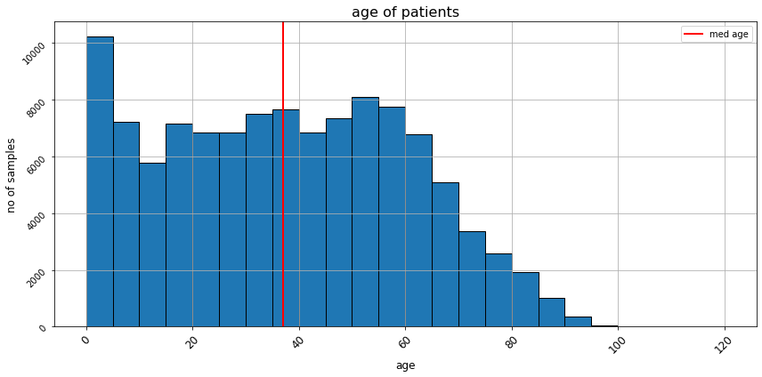

```python
bins =[0,5,10,15,20,25,30,35,40,45,50,55,60,65,70,75,80,85,90,95,100,105,110,115,120]
hist_fun(df.age , 'age of patients' , 'age' , med_age , bins , False)
```

*there are 104 age category and histogram showed up the number of each category on dataset*

```python
counts = df.diabetes.value_counts()
counts
```

```
0    102578
1      7943
Name: diabetes, dtype: int64
```

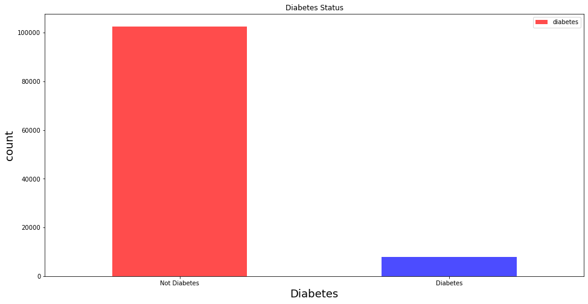

```python
bar_fun(counts ,'Diabetes', 'Diabetes Status')
plt.xticks([0, 1], ['Not Diabetes', 'Diabetes']);
```

*number of patients diabetes to not on data set*

```python
counts = df.scholarship.value_counts()
counts
```

```
0    99660
1    10861
Name: scholarship, dtype: int64
```

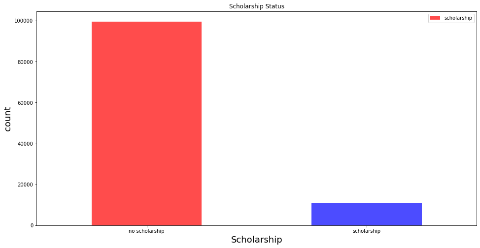

```python
bar_fun(counts , 'Scholarship' , 'Scholarship Status')
plt.xticks([0, 1], ['no scholarship', 'scholarship']);
```

*number of patients have schoolar to not on data set*

```python
counts = df.alcoholism.value_counts()
counts
```

```
0    107161
1      3360
Name: alcoholism, dtype: int64
```

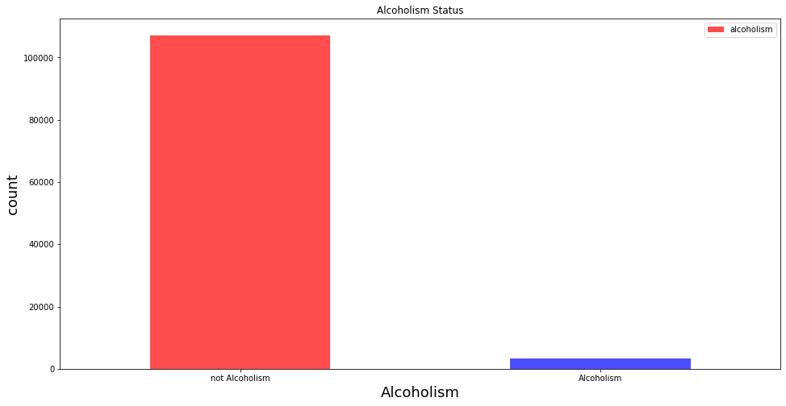

```python
bar_fun(counts , 'Alcoholism', 'Alcoholism Status')
plt.xticks([0, 1], ['not Alcoholism', 'Alcoholism']);
```

*number of patients alcoholism to not on data set*

```python
counts = df.hipertension.value_counts()
counts
```

```
0    88720
1    21801
Name: hipertension, dtype: int64
```

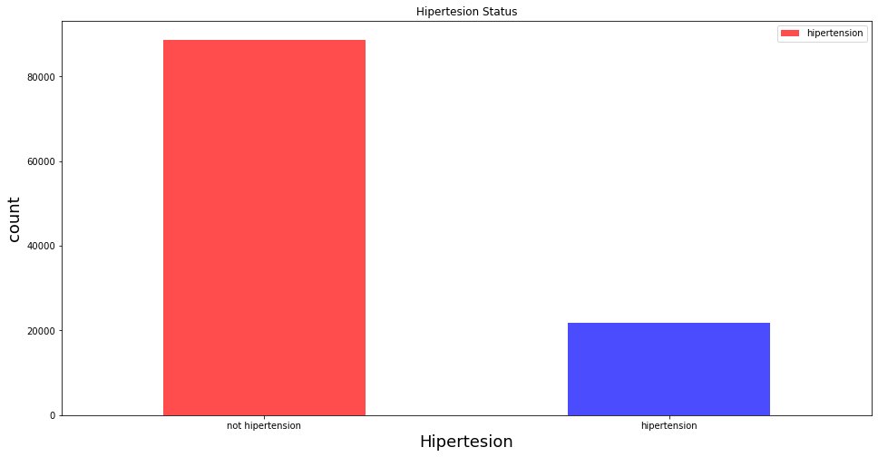

```python
bar_fun(counts , 'Hipertesion', 'Hipertesion Status')
plt.xticks([0, 1], ['not hipertension', 'hipertension']);
```

*number of patients have hipertension to not on data set*

```python
counts = df.gender.value_counts()
counts
```

```
F    71836
M    38685
Name: gender, dtype: int64
```

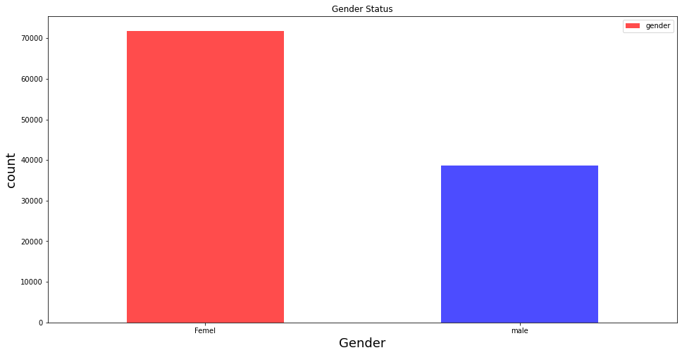

```python
bar_fun(counts , 'Gender', 'Gender Status')
plt.xticks([0,1], ['Femel', 'male']);
```

```python
counts = df.sms_received.value_counts()
counts
```

```
0    75039
1    35482
Name: sms_received, dtype: int64
```

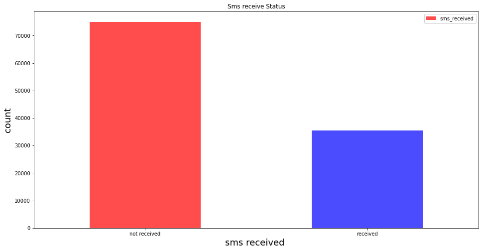

```python
bar_fun(counts , 'sms received ', 'Sms receive Status')
plt.xticks([0,1], ['not received', 'received']);
```

*number of patients receive sms to not on data set*

```python
med_waiting = df.waiting_day.mean()
```

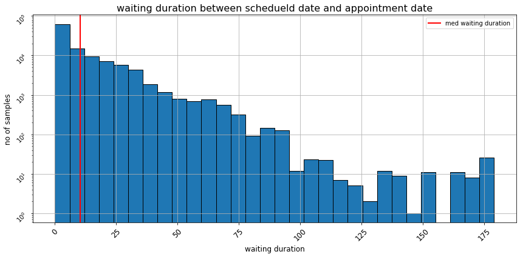

```python
bins =30
hist_fun(df.waiting_day , 'waiting duration between schedueld date and appointment date' , 'waiting duration' , med_waiting , bins , True)
```

*time duration between scheduled time and appointment time with respect to the number of recordes on data set i think this need to be calssified to labeld time duration interval for easer study and analysis and predit if it's a real cause or not*

## Ask And Answer Questions

> **1- Is neighbourhood have significant effect on the no show medical appointment ?**

> **2- what is the effect of gender on patients showing up**

> **3- what is the effect of scholarshipo on patients showing up?**

> **4- are chronical diseases as hipertension and diabetes have significant effect on patient prevent them from attending ?**

> **5- what is the effect of waiting time on patients showing up?**

> **6- what is the effect of age on patients showing up?**

> **7- are there any specific day of week on which patients don't show up**

```python
neighbor_area_len = len(df.neighborhood.unique())
```

```python
neighbor_area_count = df.neighborhood.value_counts(ascending=True)
neighbor_area_count
```

```
PARQUE INDUSTRIAL                 1
ILHAS OCEÂNICAS DE TRINDADE       2
AEROPORTO                         8
ILHA DO FRADE                    10
ILHA DO BOI                      35
                               ...
ITARARÉ                        3514
JARDIM DA PENHA                3877
RESISTÊNCIA                    4430
MARIA ORTIZ                    5805
JARDIM CAMBURI                 7717
Name: neighborhood, Length: 81, dtype: int64
```

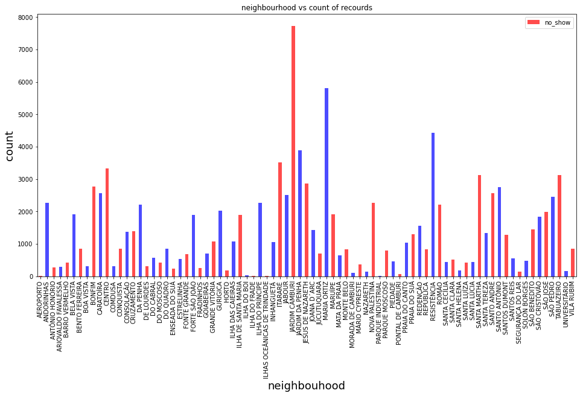

```python
neighbor_area_count = df.groupby('neighborhood').count()['no_show']
bar_fun(neighbor_area_count , 'neighbouhood' , 'neighbourhood vs count of recourds', rot=90)
```

*by invistigating the neighbour with count of no show it discoverd that area of JARDIM CAMBURI have the max number of calls for medical program and it's inconsistent data because location is not mentioned so invistigation more needed of that area to know the real cause of that*

```python
counts = df.no_show.groupby(df.gender).value_counts(normalize=True)
counts
```

```
gender  no_show
F       0          0.796885
        1          0.203115
M       0          0.800362
        1          0.199638
Name: no_show, dtype: float64
```

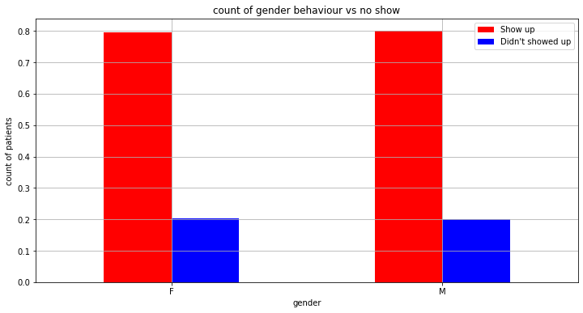

```python
bar_fun_2(counts , 'count of gender behaviour vs no show')
```

*from the chart it noticed that there are no such difference between male/female that show to that no show so gender is not significant factor on analysis*

```python
counts = df.no_show.groupby(df['scholarship']).value_counts(normalize=True)
counts
```

```
scholarship  no_show
0            0          0.801967
             1          0.198033
1            0          0.762637
             1          0.237363
Name: no_show, dtype: float64
```

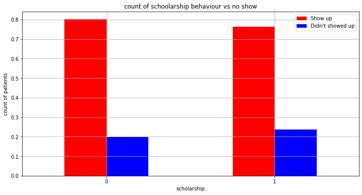

```python
bar_fun_2(counts , 'count of schoolarship behaviour vs no show')
```

*it noticed that there are about 4% percent between show and no show for patients have schoolarship so schoolarship can be considerd as significant paramter on analysis*

```python
df['chronical_disease'] = df.hipertension * df.diabetes
```

```python
counts = df.no_show.groupby(df['chronical_disease']).value_counts(normalize=True)
counts
```

```
chronical_disease  no_show
0                  0          0.796482
                   1          0.203518
1                  0          0.824083
                   1          0.175917
Name: no_show, dtype: float64
```

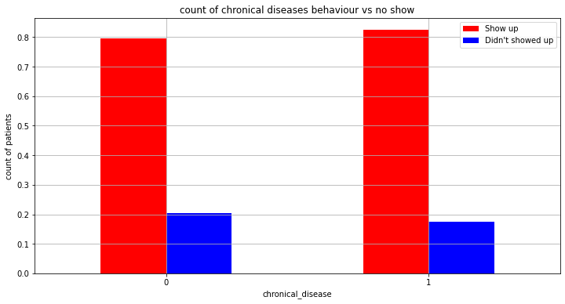

```python
bar_fun_2(counts , 'count of chronical diseases behaviour vs no show')
```

*it noticed that there are about 3% percent between show and no show for patients have chronical diseases so chronical diseases can be considerd as significant paramter on analysis*

```python
df.waiting_day.describe()
```

```
count    110521.000000
mean         10.184345
std          15.255153
min           0.000000
25%           0.000000
50%           4.000000
75%          15.000000
max         179.000000
Name: waiting_day, dtype: float64
```

```python
# Bin edges that will be used to "cut" the data into groups
bin_edges = [0, 1, 4, 8, 16, 31, 91, 180] # Fill in this list with five values you just found
```

```python
# Labels for the four time duration period groups
bin_names = ['same_day', 'few_days', 'week', '2_weeks', 'month', '3_month', 'more than three months'] # Name each acidity level category
```

```python
# Creates waiting period categorey column
df['waiting_period'] = pd.cut(df['waiting_day'], bin_edges, labels=bin_names, include_lowest=True , right = False)

# Checks for successful creation of this column
df.head()
```

|  | gender | scheduledday | appointmentday | age | neighborhood | scholarship | hipertension | diabetes | alcoholism | handcap | sms_received | no_show | appointment_day | waiting_day | chronical_disease | waiting_period |
| --- | --- | --- | --- | --- | --- | --- | --- | --- | --- | --- | --- | --- | --- | --- | --- | --- |
| 0 | F | 2016-04-29 | 2016-04-29 | 62 | JARDIM DA PENHA | 0 | 1 | 0 | 0 | 0 | 0 | 0 | Friday | 0 | 0 | same_day |
| 1 | M | 2016-04-29 | 2016-04-29 | 56 | JARDIM DA PENHA | 0 | 0 | 0 | 0 | 0 | 0 | 0 | Friday | 0 | 0 | same_day |
| 2 | F | 2016-04-29 | 2016-04-29 | 62 | MATA DA PRAIA | 0 | 0 | 0 | 0 | 0 | 0 | 0 | Friday | 0 | 0 | same_day |
| 3 | F | 2016-04-29 | 2016-04-29 | 8 | PONTAL DE CAMBURI | 0 | 0 | 0 | 0 | 0 | 0 | 0 | Friday | 0 | 0 | same_day |
| 4 | F | 2016-04-29 | 2016-04-29 | 56 | JARDIM DA PENHA | 0 | 1 | 1 | 0 | 0 | 0 | 0 | Friday | 0 | 1 | same_day |

```python
# checking that code are working write and data are grouped on time categorey
counts = df.no_show.groupby(df.waiting_period).value_counts(normalize=True)
counts
```

```
waiting_period          no_show
same_day                0          0.953529
                        1          0.046471
few_days                0          0.771107
                        1          0.228893
week                    0          0.747973
                        1          0.252027
2_weeks                 0          0.692046
                        1          0.307954
month                   0          0.674880
                        1          0.325120
3_month                 0          0.668438
                        1          0.331562
more than three months  0          0.741935
                        1          0.258065
Name: no_show, dtype: float64
```

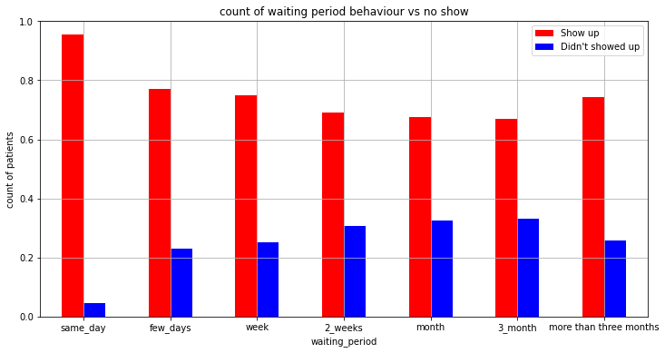

```python
bar_fun_2(counts , 'count of waiting period behaviour vs no show')
```

*by invistigating the waiting time period it was noticed that as the waiting time increase the count of no show up increase except for value of waiting time more than three months and my be this related to long term disease patients and they are very strict to there dates*

```python
# Bin edges that will be used to "cut" the data into groups
bin_edges = [0, 14, 21, 61, 115] # Fill in this list with five values you just found
```

```python
# Labels for the four age groups
bin_names = ['kids', 'teen_age', 'adult', 'senior'] # Name each acidity level category
```

```python
# Creates age_group column
df['age_groups'] = pd.cut(df['age'], bin_edges, labels=bin_names, include_lowest=True , right = False)

# Checks for successful creation of this column
df.head()
```

|  | gender | scheduledday | appointmentday | age | neighborhood | scholarship | hipertension | diabetes | alcoholism | handcap | sms_received | no_show | appointment_day | waiting_day | chronical_disease | waiting_period | age_groups |
| --- | --- | --- | --- | --- | --- | --- | --- | --- | --- | --- | --- | --- | --- | --- | --- | --- | --- |
| 0 | F | 2016-04-29 | 2016-04-29 | 62 | JARDIM DA PENHA | 0 | 1 | 0 | 0 | 0 | 0 | 0 | Friday | 0 | 0 | same_day | senior |
| 1 | M | 2016-04-29 | 2016-04-29 | 56 | JARDIM DA PENHA | 0 | 0 | 0 | 0 | 0 | 0 | 0 | Friday | 0 | 0 | same_day | adult |
| 2 | F | 2016-04-29 | 2016-04-29 | 62 | MATA DA PRAIA | 0 | 0 | 0 | 0 | 0 | 0 | 0 | Friday | 0 | 0 | same_day | senior |
| 3 | F | 2016-04-29 | 2016-04-29 | 8 | PONTAL DE CAMBURI | 0 | 0 | 0 | 0 | 0 | 0 | 0 | Friday | 0 | 0 | same_day | kids |
| 4 | F | 2016-04-29 | 2016-04-29 | 56 | JARDIM DA PENHA | 0 | 1 | 1 | 0 | 0 | 0 | 0 | Friday | 0 | 1 | same_day | adult |

```python
#checking that code are working write and all age are classified into age groups
counts = df.no_show.groupby(df.age_groups).value_counts(normalize=True)
counts
```

```
age_groups  no_show
kids        0          0.791806
            1          0.208194
teen_age    0          0.744026
            1          0.255974
adult       0          0.792664
            1          0.207336
senior      0          0.848046
            1          0.151954
Name: no_show, dtype: float64
```

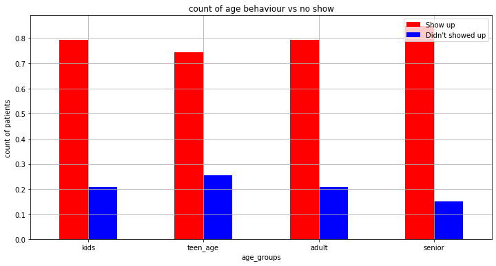

```python
bar_fun_2(counts , 'count of age behaviour vs no show')
```

*it noticed that the teen age area age category the highes count of patients didn't show up*

```python
#checking that code are working write and all age are classified into age groups
counts = df.no_show.groupby(df.appointment_day).value_counts(normalize=True)
counts
```

```
appointment_day  no_show
Friday           0          0.787739
                 1          0.212261
Monday           0          0.793554
                 1          0.206446
Saturday         0          0.769231
                 1          0.230769
Thursday         0          0.806506
                 1          0.193494
Tuesday          0          0.799126
                 1          0.200874
Wednesday        0          0.803139
                 1          0.196861
Name: no_show, dtype: float64
```

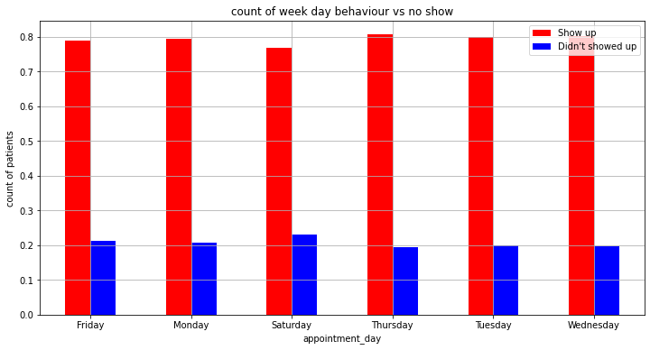

```python
bar_fun_2(counts , 'count of week day behaviour vs no show')
```

*by invistigating the data it's noticed that saturday has the max number of people didn't show up*

## limitations

> *2-the actual location of neighnourhood is not mentioned so we can't judge exactly what is the effect of neighbourhood on data analysis*

> *3- handicap column contains values other than 0 , 1 whish is not clear what is that exactly means so i change all the values other than one to one*

> *4- as there error in age recording also errors on schedueld date after appointment date this makes some doubt about data recording*

> *5- it's not mentioned if this dataset is enough to evaluate a huge governemental project as bolsa familia because it's not clear how mush time this dataset data collected time*

## Summary And Conclusion

> *1- nighbourhood supposed to add more informations to has significant effect od data analysis*

> *2- patient id and appointment id has no significant effect on data specially there are 48228 record repeated for the same patients*

> *4- schoolar ship has significant effect on data anlysis*

> *5- chronical disease have significant effect on data anlysis*

> *6- waiting days has significant effect on data analysis*

> *7- age has significat effect on data analysis*

> *8- saturday is the most highest value of patients didn't show up*